[figure not shown]

# A Vision of the Future of Mathematics

[Florian Breuer](https://florianbreuer.github.io/florianbreuer/)<sup>1</sup>

## Math is hard

Mathematics has been struck by an asteroid. I don’t mean the [nefarious action of a powerful corporation](https://openai.com/index/sharing-ai-progress-in-mathematics/), but rather the empirical fact that AI systems are capable of superhuman mathematical ability. How this fact was revealed is not important; under different circumstances it may have been revealed sooner or later, or more gently, but ultimately the fact remains the same. We need to face it.

I think this fact reveals more about humans than about artificial intelligence. Humans are not very good at mathematics. It doesn’t come naturally to us and learning it is a slow, deliberate and (for many) painful process. Some never learn it at all. Our brains are not wired for mathematics; evolution never selected for it. What mathematical ability we do have is a side-effect of other, evolved abilities such as language and navigating a 3D world. Is it surprising that machines, trained first on the entirety of human mathematical knowledge, and then post-trained via RLVR<sup>2</sup> on huge numbers of increasingly hard mathematical and coding problems, eventually learn to outperform us? The same happened with chess, and then Go. David Harvey<sup>3</sup> points out that this means mathematics is only 30 years harder than chess (and 10 years harder than Go).

## Why we did Mathematics

Much has been written about how the purpose of mathematics is, has always been and must remain the human understanding of mathematics. I disagree.

We should examine why we do mathematics in the first place. The mathematical community is a diverse ecosystem of humans, and different members have different styles, abilities and motivations. Some are motivated by the pursuit of truth and beauty. Others live for the competitive thrill – to be smarter and better than others at this difficult activity. Yet others want to serve society by advancing the frontier of knowledge, leading to innovations which improve lives. Or we do it just because it’s enjoyable, and we’ve found a niche where we get paid for doing what we love. For most of us, it will be some combination of the above.<sup>4</sup><sup>,5</sup>

So much for our own motivations; why should society support this activity, through salaries and grants? First, to teach. Mathematical thinking (problem solving, critical thinking, the ability to deal with abstraction), however puny in absolute terms, is highly valuable and transferable. As long as people need skills at all, this is among the skills they benefit most from learning. I also expect learning to remain a social activity – it requires almost superhuman willpower to push through the productive struggle needed to rewire your brain if you just study by yourself, with or without the help of AI tutors.

Just as importantly, mathematics underpins the other sciences and technology; it forms the wellspring of the famous innovation pipeline. Pure mathematics leads to applied mathematics leads to other sciences, finally to engineering and valuable technologies. One oft-quoted example is how centuries of number theory, the purest intellectual pursuit, led to public-key cryptography, without which the entire online economy could not function. We feel that even our most abstract and esoteric discoveries might one day, perhaps in 10 or 50 or 200 years, prove a vital input for an as-yet unimaginable new technology.

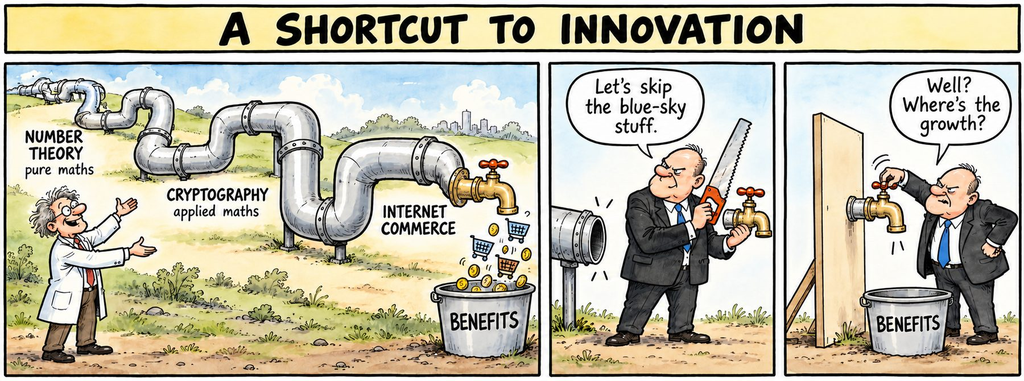

We grow indignant when those who pay us demand we demonstrate how our work will lead to immediate, real-world impact.

## The future?

Many have written about how exciting the new mathematical future will be. Where we previously explored the alien landscape of mathematics on our hands and knees, we now get to drive around on AI-powered jeeps! After all, AI has only solved problem-solving and theorem-proving, which was never the point of mathematics (since mid-2026, anyway). Humans still ask the questions and build the new concepts. Peter Scholze is not yet obsolete, right?

Maybe AI will finally hit the skeptics’ wall,<sup>6</sup> but I doubt it. If not, within the next year AIs will ask the better questions, build the more fruitful theories and push the mathematical frontier increasingly beyond our feeble human understanding.

The innovation pipeline will be supercharged. AIs that understand all of mathematics at once will spot applications that would never occur to one of us. They will convert these mathematical discoveries into new scientific insights and technological marvels with increasing speed and autonomy. The spigot at the end of the pipeline will become a cornucopia – if we live to see it.<sup>7</sup> For the rest of society, this will be a good thing – just like weaving machines gave us cheaper clothes and the Luddites became a footnote of history. But human mathematicians can no longer cite the innovation pipeline in grant applications.

I predict that mathematics will crystallise into a database of formal statements and proofs, initially in Lean, but occasionally refactored as more suitable formal systems are invented. This monolith<sup>8</sup> will grow outwards at a dizzying pace with no regard for human understanding. After all, the mathematicians and scientists using it won’t be human.

What will we, mere human mathematicians, do? We will probably keep teaching mathematics and mathematical thinking. Many of us will keep doing mathematics, human mathematics, fun and beautiful and insightful – and far from the frontier of knowledge. Some will mine the monolith (with AI help), and bring back shiny mathematical nuggets to digest and share. Others will close themselves off, jealously guarding their “Human Mathematics” from any AI contamination.

What, then, of the human understanding of mathematics? It is vital for teaching mathematical thinking, and will continue to bring us beauty and joy, but humans will no longer understand the research frontier. We must make peace with that.

Mathematics was fun when we were children and knew so much less than the adults. It was recreational and a valuable learning experience. We are about to relive this childhood.<sup>9</sup> Can’t we just drop our conceits and status games and enjoy it?

## Important caveats

The above vision of the future assumes the development of AI goes broadly well for humanity. This is an important assumption, and does not automatically hold unless we solve the alignment problem, which is hard.

The biggest problem with this vision is that in it we give up control of mathematics to the machines. This seems unavoidable, since the machines are so much better at it, and at producing the useful applications of it, than we are. This abdication will happen automatically, unless we somehow stop the development of powerful AI. The danger is that mathematics is not unique here – there are many domains in which AI will do better than humans, and for each domain individually it will seem rational to hand control to the more competent machines. Taken together, this leads to the [gradual disempowerment](https://arxiv.org/abs/2501.16946) of humanity. First, the machines came for the weavers – now they come for the rest of us. [Scott Alexander argues](https://www.astralcodexten.com/p/against-against-handover) that handing over to a perfectly aligned superintelligence may well be our best bet, but it is still extremely dangerous.

The vision also doesn’t address what we should do in the short term. Right now, for example, my university pays me to spend 40% of my time teaching, 40% on research and 20% on “service”. Setting aside the joke that my allocation is really 80-20-60, how can I justify 40% of my salary for what has become recreational mathematics? There are still research questions where a human + AI may be better than AI alone, and getting results is urgent, for example in post-quantum cryptography. In my case, I am reskilling to work on AI safety<sup>10</sup> – I’m putting the transferability of my mathematical skills to the test.

But what of our students? The development of mathematical thinking skills is just as useful as ever, and the work of producing a thesis builds this – provided you don’t outsource this task to an AI. The value of a thesis is no longer the results therein (AI can produce these in an afternoon), but in the skills of the candidate. There are many places to put these skills to good use – starting with AI safety research. And if we do reach AI utopia, a lifetime of joyous mathematics awaits!

## Notes

[^1]: My opinions are my own. Nevertheless, I benefited from conversations with David Harvey, Fabien Pazuki, Stephan Tornier and others. ↩
[^2]: Reinforcement learning from verifiable rewards. ↩
[^3]: Private communication. ↩
[^4]: The pursuit of material gain, for money and power, is less common among mathematicians, since those who want these things, and find themselves with mathematical talent, can go work in finance and get rich. ↩
[^5]: Also, at least in my case, my sense of self-worth rests on my ability to do mathematics (however unremarkable by mathematicians’ standards). The recent developments are a bitter pill to swallow. ↩
[^6]: There is a theoretical barrier that AI progress is perpetually about to hit. It is always located slightly ahead of the current frontier, and has the unusual property of retreating at exactly the speed of approach. ↩
[^7]: Ensuring AI turns out well for humanity is the most important unsolved problem in the world now. Mathematicians have a role to play here, too! ↩
[^8]: Starting, perhaps, with the [Tau Ceti Project](https://taucetiproject.org/). It may be surrounded by a larger cloud of less formal mathematics. ↩
[^9]: Assuming we can pay our bills! ↩
[^10]: I’m starting with a course at [BlueDot](https://bluedot.org/). Other resources for mathematicians looking to get into AI safety research include [MAISI](https://maisi.org/), [Iliad](https://www.iliad.ac/calendar) and the article [Math for AI safety: an invitation for mathematicians](https://arxiv.org/abs/2609.15289) by Lionel Levine. ↩